# Summary of Newspaper Closure Dataset

Simon J. KIss

19/05/2021

## R Markdown

This is how the data-set is structured right now.

| status | province | municipality | CSD code | year | turnout | number of candidates | margin_percent | na | n | acclaimed | treatment |
| --- | --- | --- | --- | --- | --- | --- | --- | --- | --- | --- | --- |
| 0 | Alberta | Calgary | 4806016 | 2004 | 19.80 | 7 | 0.74 | 0 | NA | NA | 0 |
| 0 | Alberta | Calgary | 4806016 | 2007 | 32.90 | 9 | 0.44 | 0 | NA | NA | 0 |
| 0 | Alberta | Calgary | 4806016 | 2010 | 53.39 | 15 | 0.08 | 0 | NA | NA | 0 |
| 0 | Alberta | Calgary | 4806016 | 2013 | 39.43 | 9 | 0.52 | 0 | NA | NA | 0 |
| -1 | Alberta | Calgary | 4806016 | 2017 | 58.10 | 10 | 0.08 | 0 | NA | NA | 1 |
| 0 | Alberta | Canmore | 4815023 | 2007 | 24.56 | 1 | NA | 1 | 1 | 1 | 0 |
| 0 | Alberta | Canmore | 4815023 | 2010 | 42.03 | 2 | 0.06 | 0 | NA | NA | 0 |
| -1 | Alberta | Canmore | 4815023 | 2013 | 37.64 | 3 | 0.57 | 0 | NA | NA | 1 |
| -1 | Alberta | Canmore | 4815023 | 2017 | NA | 2 | 0.29 | 1 | NA | NA | 1 |
| -1 | Alberta | Canmore | 4815023 | 2017 | NA | 2 | NA | 2 | NA | NA | 1 |
| 0 | Alberta | Edmonton | 4811061 | 2004 | 41.80 | 8 | 0.08 | 0 | NA | NA | 0 |
| 0 | Alberta | Edmonton | 4811061 | 2007 | 27.20 | 9 | 0.40 | 0 | NA | NA | 0 |
| 0 | Alberta | Edmonton | 4811061 | 2010 | 33.40 | 7 | 0.26 | 0 | NA | NA | 0 |
| 0 | Alberta | Edmonton | 4811061 | 2013 | 34.50 | 6 | 0.43 | 0 | NA | NA | 0 |
| 0 | Alberta | Edmonton | 4811061 | 2017 | 31.50 | 13 | 0.66 | 0 | NA | NA | 0 |
| 0 | Alberta | Grande Prairie | 4819012 | 2007 | 29.20 | 2 | 2.42 | 0 | NA | NA | 0 |
| 0 | Alberta | Grande Prairie | 4819012 | 2010 | 24.00 | 5 | 0.15 | 0 | NA | NA | 0 |
| 0 | Alberta | Grande Prairie | 4819012 | 2013 | 20.95 | 2 | 1.17 | 0 | NA | NA | 0 |
| 0 | Alberta | Grande Prairie | 4819012 | 2017 | 24.00 | 4 | 0.41 | 0 | NA | NA | 0 |
| 0 | Alberta | Jasper | 4815033 | 2007 | 37.22 | NA | NA | 2 | NA | NA | 0 |

Right now we have data on 116 municipalities. They come from a basically a combined public data-set that has tracked newspaper closures and a data-set of historic election results. There’s a big range of municipalities in here, from large metropolises to rural townships, so I’m going to guess we’ll want to include some kind of control for population size.

WE have three dependent variables:

1. Margin of Victory (Percent)
2. Turnout (percent)
3. Number of mayoral candidates.

In terms of newspaper closures, we have set up the data where each municipality enters the data-set with a value of 0, and then receives a -1 each time we have a record of a newspaper closure before that election-year. Once it has suffered a newspaper closure, that score stays with it through the data-set, so the treatment is I guess hypothesized to have lasting effects. If another newspaper is closed, then the score goes down by one again. So with this, we can quickly define a dichotomous variable 0 or 1 whether a municipality in a year has had a newspaper closure, or we can try to model the effects linearly.

The treatment is distributed as follows:

The treatment and dependent variables are distributed as follows. So there are some weird outliers here. For example, one municipality has 6 newspaper closures recorded; one municipality had like 40 candidates for mayor But those can be dealt with, although that will then reduce sample size a bit.

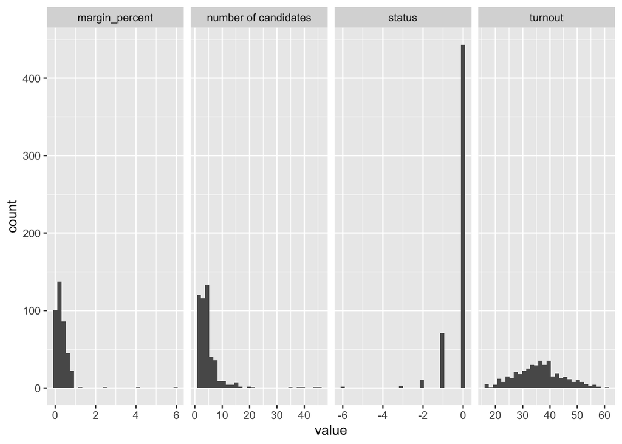